# P4 - CommUTEC

## Continuación

– Residual standard error: 1.766 on 171 degrees of freedom

– Multiple R-squared: 0.3884, Adjusted R-squared: 0.3598

– F-statistic: 13.58 on 8 and 171 DF, p-value: 3.804e-15

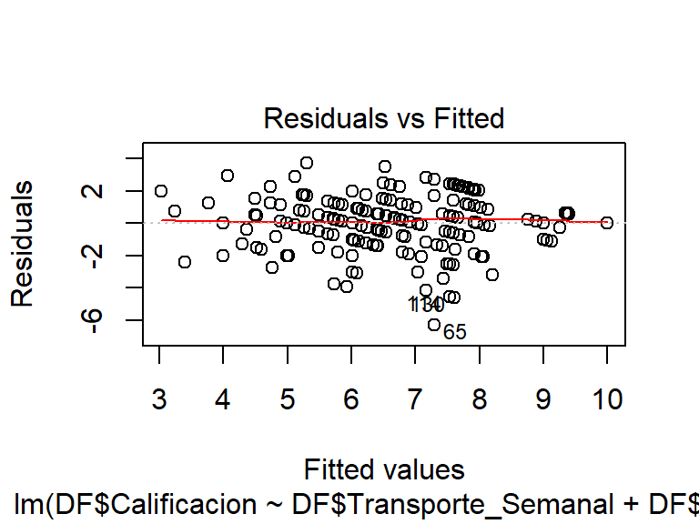

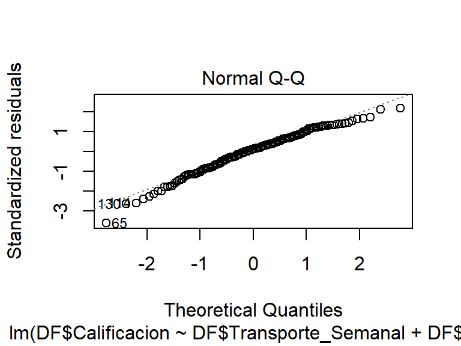

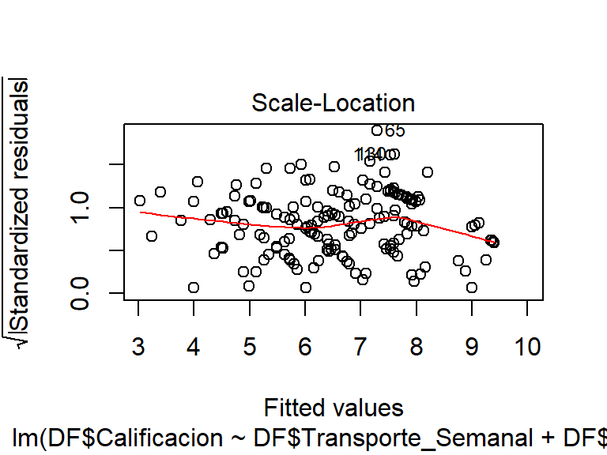

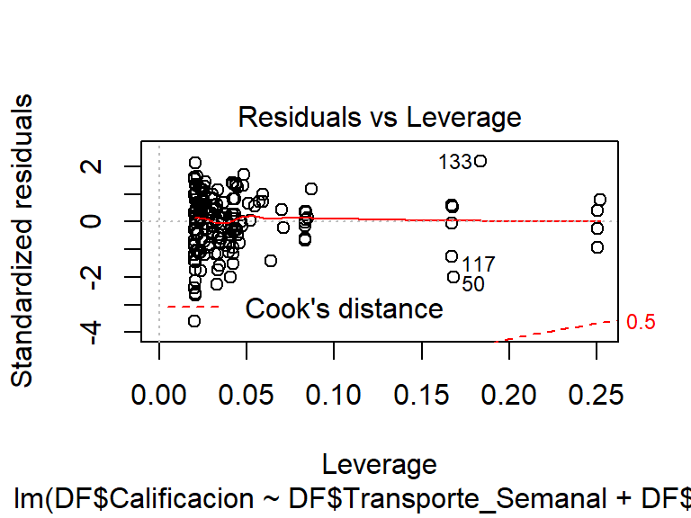

```
##
##  One Sample t-test
##
## data:  R_Calif1$coefficients
## t = 0.025212, df = 8, p-value = 0.9805
## alternative hypothesis: true mean is not equal to 0
## 95 percent confidence interval:
##  -2.793832  2.855599
## sample estimates:
##  mean of x
## 0.03088347
```

## Conclusiones

## Conclusiones

**#** Se encontró dependencia de algunas variables con respecto a otras, siendo las más significativas: -El nivel de estrés explica el 7.6% de la variación en las horas de sueño diarias. -El tiempo de transporte semanal explica el 29.78% de la variación de la calificación del transporte. -El modelo con las variables independientes nivel de estrés y tiempo de transporte semanal explica el 10.36% de la variación de las horas de sueño diarias.

**#** De los modelos entre variables planteadas no se pudo rechazar estadísticamente al 5% de signifancia la no dependencia del número de cursos reprobados con respecto al tiempo de transporte diario.

**#** Respecto a los modelos obtenidos por regresión, no se encontró ninguno que sea lo sufientemente robusto como para realizar predicción sobre alguna variable dependiente.

## Bibliografía

- https://gestion.pe/tendencias/lima-ciudades-peor-trafico-269483-noticia/
- https://amp.milenio.com/especiales/estres-cronico-como-identificarlo